```python
import pandas as pd
import numpy as np
import matplotlib.pyplot as plt
```

```python
df = pd.read_csv(r"C:\Users\Admin\online_learning_platform.csv")
```

# 1: Dataset Understanding

## Display first 5 records

```python
df.head()
```

|  | user_id | age_group | role | primary_platform | learning_device | hours_per_week | learning_purpose | content_type_preference | completion_rate_percent | satisfaction_score |
| --- | --- | --- | --- | --- | --- | --- | --- | --- | --- | --- |
| 0 | 1 | 35-44 | Working Professional | edX | Laptop | 10 | Career Growth | Text | 34 | 5 |
| 1 | 2 | 45+ | Other | edX | Mobile | 12 | Career Growth | Text | 17 | 3 |
| 2 | 3 | 25-34 | Freelancer | Skillshare | Desktop | 2 | Academic | Text | 67 | 9 |
| 3 | 4 | 45+ | Working Professional | Udemy | Mobile | 3 | Career Growth | Mixed | 25 | 5 |
| 4 | 5 | 45+ | Working Professional | Khan Academy | Mobile | 10 | Hobby | Video | 81 | 5 |

## Find number of rows and columns

```python
df.shape
```

```
(420, 10)
```

## Display column names

```python
df.columns
```

```
Index(['user_id', 'age_group', 'role', 'primary_platform', 'learning_device',
       'hours_per_week', 'learning_purpose', 'content_type_preference',
       'completion_rate_percent', 'satisfaction_score'],
      dtype='str')
```

## Check data types

```python
df.dtypes
```

```
user_id                    int64
age_group                    str
role                         str
primary_platform             str
learning_device              str
hours_per_week             int64
learning_purpose             str
content_type_preference      str
completion_rate_percent    int64
satisfaction_score         int64
dtype: object
```

## Complete dataset information

```python
df.info()
```

```
<class 'pandas.DataFrame'>
RangeIndex: 420 entries, 0 to 419
Data columns (total 10 columns):
 #   Column                   Non-Null Count  Dtype
---  ------                   --------------  -----
 0   user_id                  420 non-null    int64
 1   age_group                420 non-null    str
 2   role                     420 non-null    str
 3   primary_platform         420 non-null    str
 4   learning_device          420 non-null    str
 5   hours_per_week           420 non-null    int64
 6   learning_purpose         420 non-null    str
 7   content_type_preference  420 non-null    str
 8   completion_rate_percent  420 non-null    int64
 9   satisfaction_score       420 non-null    int64
dtypes: int64(4), str(6)
memory usage: 50.9 KB
```

### The dataset contains 420 users and 10 variables. It includes information about user demographics, platform usage, learning device, weekly learning hours, learning purpose, preferred content type, course completion rate and satisfaction score.

# 2: Data Preparation

## Check missing values

```python
df.isnull().sum()
```

```
user_id                    0
age_group                  0
role                       0
primary_platform           0
learning_device            0
hours_per_week             0
learning_purpose           0
content_type_preference    0
completion_rate_percent    0
satisfaction_score         0
dtype: int64
```

## Check duplicate records

```python
df.duplicated().sum()
```

```
np.int64(0)
```

## Check data types

```python
df.dtypes
```

```
user_id                    int64
age_group                    str
role                         str
primary_platform             str
learning_device              str
hours_per_week             int64
learning_purpose             str
content_type_preference      str
completion_rate_percent    int64
satisfaction_score         int64
dtype: object
```

## Check unique values

```python
print(df["age_group"].unique())
print(df["role"].unique())
print(df["primary_platform"].unique())
print(df["learning_device"].unique())
print(df["learning_purpose"].unique())
print(df["content_type_preference"].unique())
```

```
<ArrowStringArray>
['35-44', '45+', '25-34', '18-24', 'Under 18']
Length: 5, dtype: str
<ArrowStringArray>
['Working Professional', 'Other', 'Freelancer', 'Student']
Length: 4, dtype: str
<ArrowStringArray>
['edX', 'Skillshare', 'Udemy', 'Khan Academy', 'YouTube', 'Coursera']
Length: 6, dtype: str
<ArrowStringArray>
['Laptop', 'Mobile', 'Desktop', 'Tablet']
Length: 4, dtype: str
<ArrowStringArray>
['Career Growth', 'Academic', 'Hobby', 'Skill Upgrade']
Length: 4, dtype: str
<ArrowStringArray>
['Text', 'Mixed', 'Video']
Length: 3, dtype: str
```

## Check numerical ranges

```python
print(df["hours_per_week"].min())
print(df["hours_per_week"].max())

print(df["completion_rate_percent"].min())
print(df["completion_rate_percent"].max())

print(df["satisfaction_score"].min())
print(df["satisfaction_score"].max())
```

```
1
20
10
100
1
10
```

### I checked the dataset for missing values, duplicate records, incorrect data types and unusual values. No missing values or duplicate records were found. The numerical variables were already stored in suitable formats, so no major data cleaning was required.

# Exploratory Data Analysis

## 1. Distribution of users across age groups

```python
df["age_group"].value_counts()
```

```
age_group
35-44       98
Under 18    91
45+         77
25-34       77
18-24       77
Name: count, dtype: int64
```

### The 35-44 age group has the highest number of users with 98 users. The distribution shows that the platform is being used by people from different age groups rather than being concentrated in only one age segment.

## 2. Hours Spent on Learning Per Week

```python
df["hours_per_week"].describe()
```

```
count    420.000000
mean      10.476190
std        5.708253
min        1.000000
25%        5.750000
50%       11.000000
75%       15.000000
max       20.000000
Name: hours_per_week, dtype: float64
```

```python
df["hours_per_week"].mean()
```

```
np.float64(10.476190476190476)
```

```python
print("Minimum:", df["hours_per_week"].min())
print("Maximum:", df["hours_per_week"].max())
```

```
Minimum: 1
Maximum: 20
```

### Users spend an average of approximately 10.48 hours per week on learning activities. The learning time varies between users, showing that some users spend considerably more time on the platform than others.

# 3.Platform Usage Patterns

```python
df["primary_platform"].value_counts()
```

```
primary_platform
Skillshare      79
Khan Academy    75
Coursera        69
Udemy           68
edX             66
YouTube         63
Name: count, dtype: int64
```

```python
df.groupby("primary_platform")["hours_per_week"].mean().sort_values(
    ascending=False
)
```

```
primary_platform
edX             11.242424
Udemy           11.102941
Coursera        10.565217
Skillshare      10.341772
Khan Academy     9.906667
YouTube          9.746032
Name: hours_per_week, dtype: float64
```

### Users are distributed across multiple online learning platforms. The average learning time also differs between platforms, which suggests that users may interact with different platforms at different levels of intensity.

# 4.Preferred Learning Content Types

```python
df["content_type_preference"].value_counts()
```

```
content_type_preference
Text     148
Video    146
Mixed    126
Name: count, dtype: int64
```

### Users show different preferences for learning content such as text, video and other formats.

# Engagement Analysis

## 1. Average learning hours by age group

```python
df.groupby("age_group")["hours_per_week"].mean().sort_values(
    ascending=False
)
```

```
age_group
25-34       11.623377
45+         10.688312
18-24       10.272727
Under 18    10.098901
35-44        9.918367
Name: hours_per_week, dtype: float64
```

### 25–34 is having 11.62 hours/week

So this age group has the highest average learning time.

## 2. Relationship Between Learning Hours and Completion Rate

```python
correlation = df["hours_per_week"].corr(
    df["completion_rate_percent"]
)

print("Correlation:", correlation)
```

```
Correlation: -0.03332379948612302
```

### A correlation close to 0 means there is almost no linear relationship between the two variables.

So, spending more hours on the platform does not automatically mean that a user will have a higher completion rate.

## 3. Comparison of engagement across different platforms or devices

```python
# Engagement Across Different Platforms
platform_engagement = df.groupby(
    "primary_platform"
)["hours_per_week"].mean().sort_values(ascending=False)

print(platform_engagement)
```

```
primary_platform
edX             11.242424
Udemy           11.102941
Coursera        10.565217
Skillshare      10.341772
Khan Academy     9.906667
YouTube          9.746032
Name: hours_per_week, dtype: float64
```

### Engagement levels vary across learning platforms. Users of some platforms spend more time learning each week, which may indicate differences in course structure, content quality, user motivation or platform experience.

```python
#Engagement Across Different Devices
device_engagement = df.groupby(
    "learning_device"
)["hours_per_week"].mean().sort_values(ascending=False)

print(device_engagement)
```

```
learning_device
Laptop     11.672897
Tablet     10.333333
Desktop    10.109890
Mobile      9.765766
Name: hours_per_week, dtype: float64
```

### Laptop users appear to be more engaged when engagement is measured by weekly learning hours. This could indicate that users prefer larger screens for longer learning sessions.

# Course Completion Analysis

### 1. Overall Course Completion Rate

```python
df["completion_rate_percent"].mean()
```

```
np.float64(53.93571428571428)
```

```python
df["completion_rate_percent"].describe()
```

```
count    420.000000
mean      53.935714
std       26.638357
min       10.000000
25%       30.000000
50%       54.000000
75%       77.250000
max      100.000000
Name: completion_rate_percent, dtype: float64
```

### The average course completion rate is approximately 53.94%. This means that on average users complete around half of their assigned or enrolled course content.

### 2. Relationship Between Engagement and Completion

```python
df["engagement_level"] = pd.qcut(
    df["hours_per_week"],
    q=3,
    labels=["Low", "Medium", "High"]
)
```

```python
engagement_completion = df.groupby(
    "engagement_level",
    observed=True
)["completion_rate_percent"].mean()

print(engagement_completion)
```

```
engagement_level
Low       57.204082
Medium    50.072848
High      54.778689
Name: completion_rate_percent, dtype: float64
```

### 3. Impact of Learning Purpose

```python
completion_purpose = df.groupby(
    "learning_purpose"
)["completion_rate_percent"].mean().sort_values(
    ascending=False
)

print(completion_purpose)
```

```
learning_purpose
Skill Upgrade    59.209524
Academic         53.782178
Career Growth    52.681034
Hobby            49.928571
Name: completion_rate_percent, dtype: float64
```

Skill Upgrade is approximately 59.21%

This is the highest average completion rate among the learning-purpose groups.

Users learning for skill improvement have the highest average completion rate, at around 59.21%. This suggests that users with a specific and practical learning goal may be more likely to continue and complete their courses.

# User Satisfaction Analysis

## 1. Relationship Between Completion Rate and Satisfaction

```python
correlation = df["completion_rate_percent"].corr(
    df["satisfaction_score"]
)

print("Correlation:", correlation)
```

```
Correlation: 0.022571686246480458
```

### Users with higher completion rates are not necessarily more satisfied than users with lower completion rates.

### 2. Satisfaction by Age Group

```python
satisfaction_age = df.groupby(
    "age_group"
)["satisfaction_score"].mean().sort_values(
    ascending=False
)

print(satisfaction_age)
```

```
age_group
25-34       5.662338
35-44       5.295918
45+         5.285714
Under 18    5.098901
18-24       4.805195
Name: satisfaction_score, dtype: float64
```

### Satisfaction varies across age groups. The 25-34 age group has the highest average satisfaction score at approximately 5.66 out of 10.

### 3.Satisfaction by Platform

```python
satisfaction_platform = df.groupby(
    "primary_platform"
)["satisfaction_score"].mean().sort_values(
    ascending=False
)

print(satisfaction_platform)
```

```
primary_platform
Khan Academy    5.693333
Skillshare      5.468354
edX             5.257576
Coursera        5.144928
YouTube         5.126984
Udemy           4.588235
Name: satisfaction_score, dtype: float64
```

### Satisfaction differs across learning platforms. Khan Academy users have the highest average satisfaction score at approximately 5.69 out of 10. This difference could be related to content, usability or the type of learning experience offered, but the dataset alone cannot determine the exact cause.

# Data Visualization

### Engagement Level Distribution

```python
df["engagement_level"] = pd.qcut(
    df["hours_per_week"],
    q=3,
    labels=["Low", "Medium", "High"]
)
```

```python
df["engagement_level"].value_counts()
```

```
engagement_level
Medium    151
Low       147
High      122
Name: count, dtype: int64
```

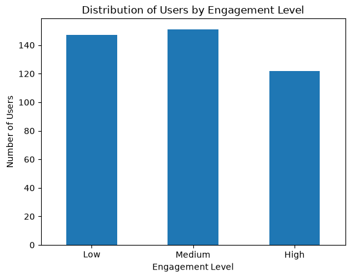

```python
df["engagement_level"].value_counts().sort_index().plot(
    kind="bar"
)

plt.title("Distribution of Users by Engagement Level")
plt.xlabel("Engagement Level")
plt.ylabel("Number of Users")
plt.xticks(rotation=0)

plt.show()
```

### This chart divides users into low, medium and high engagement groups based on their weekly learning hours. It helps identify how the overall user base is distributed according to learning activity.

### Completion Rate by Learning Purpose

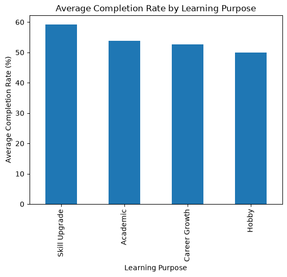

```python
purpose_completion = df.groupby(
    "learning_purpose"
)["completion_rate_percent"].mean().sort_values(
    ascending=False
)

purpose_completion.plot(kind="bar")

plt.title("Average Completion Rate by Learning Purpose")
plt.xlabel("Learning Purpose")
plt.ylabel("Average Completion Rate (%)")

plt.show()
```

### Users learning for Skill Upgrade have the highest average completion rate. This suggests that users with a specific practical goal may be more likely to complete their learning.

### Satisfaction by Device

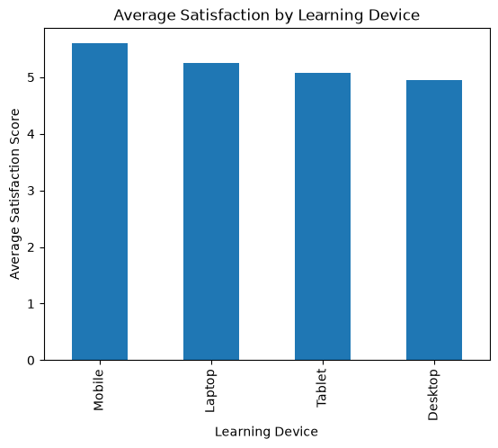

```python
device_satisfaction = df.groupby(
    "learning_device"
)["satisfaction_score"].mean().sort_values(
    ascending=False
)

device_satisfaction.plot(kind="bar")

plt.title("Average Satisfaction by Learning Device")
plt.xlabel("Learning Device")
plt.ylabel("Average Satisfaction Score")

plt.show()
```

### Mobile users have the highest average satisfaction among the device groups. This suggests that the mobile experience is relatively well received by users.

### Platform Usage Pattern

```python
platform_users = df["primary_platform"].value_counts()

print(platform_users)
```

```
primary_platform
Skillshare      79
Khan Academy    75
Coursera        69
Udemy           68
edX             66
YouTube         63
Name: count, dtype: int64
```

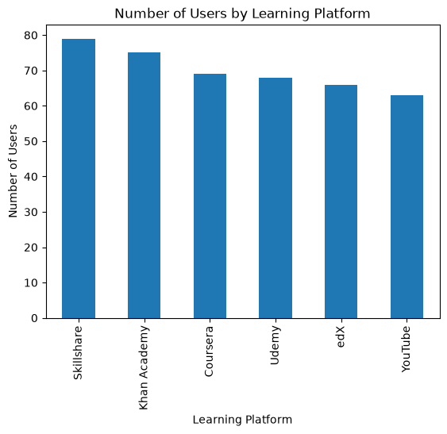

```python
platform_users.plot(kind="bar")

plt.title("Number of Users by Learning Platform")
plt.xlabel("Learning Platform")
plt.ylabel("Number of Users")

plt.show()
```

### The chart shows how the user base is distributed across different learning platforms. This can help the company understand which platforms are commonly used by its customers.

# Business Insights

### 5. Users spend an average of around 10.48 hours per week learning. However, learning hours have almost no relationship with completion rate.

### 6. Satisfaction and completion rate are also only very weakly related. This means a user can be satisfied with the platform without necessarily completing more courses.

### 7. User behavior differs across age groups, platforms, devices and learning purposes. Therefore, the company should avoid using the same engagement strategy for every user.

# Business Recommendations

### 1 - Improve Completion Support

The platform should introduce progress reminders, milestone notifications and smaller learning targets to encourage users to complete their courses.

### 2 - Personalize Learning

Learning recommendations should be based on the user's learning purpose, age group, device and previous activity instead of giving every user the same content.

### 4 - Focus on User Engagement

Instead of measuring engagement only through hours spent, the company should also track course progress, completed lessons, return frequency and interaction with learning content.

### 5 - Monitor Satisfaction Separately

Satisfaction and completion should be treated as separate KPIs because the analysis does not show a strong relationship between them. Regular feedback surveys can help identify specific user experience problems.